# How does social media use relate to healthy habits in university students?

25/04/2021

```r
knitr::opts_chunk$set(echo = TRUE, message = FALSE, warning = FALSE)
library(tidyverse)
library(janitor)
library(skimr)
library(dplyr)
library(readxl)
library(gridExtra)
library(plyr)
library(cowplot)
library(gt)
```

# 1 Executive Summary

Social media is pervasive in the lives of young people. The report is based on a survey of university students which investigated links between social media use and markers of physical and mental health. Findings demonstrated that either: healthy habits and social media posses no link (as with sleep and study time) or increased social media usage is associated with poorer health outcomes (as with stress and communication). The positive exception is that students who dislike social media use it less, suggesting intentional use. Findings are purely correlational, and leaves room for further studies to be conducted into causal links.

# 2 IDA

The variables surveyed were age, gender, hours spent on social media daily, whether social media is one’s main source of digital communication, average sleep hours per night, average study hours per day, stress levels, reasons for social media use, enjoyment levels of social media, attempts to reduce social media usage, and whether such attempts were successful. Scales from 1-5 measured more subjective constructs for comparative utility.

Data should be accurate as it was gathered anonymously without incentive to alter responses. However, data was not randomly selected. The respondents were almost entirely from the University of Sydney, and the survey was distributed via link the authors’ friends so may not reflect the diversity of ages and disciplines of university students. The sample may be biased, thus not generalising to the entire student population.

```r
### Rename column names
x = raw %>% janitor::clean_names()
colnames(x)[1] = "time"
colnames(x)[2] = "age"
colnames(x)[3] = "gender"
colnames(x)[4] = "apps_using"
colnames(x)[5] = "hours_spent"
colnames(x)[6] = "main_source_or_not"
colnames(x)[7] = "talk_or_face"
colnames(x)[8] = "sleep_hours_average"
colnames(x)[9] = "study_hours_average"
colnames(x)[10] = "stress_level"
colnames(x)[11] = "balanced_diet"
colnames(x)[12] = "reason_for_social_media"
colnames(x)[13] = "social_media_like_level"
colnames(x)[14] = "reduce_phone_usage"
colnames(x)[15] = "attempt_successful"
x = x %>% drop_na(attempt_successful)
x = x %>% filter(gender=="Male" | gender== "Female" | gender=="Prefer not to say")
glimpse(x)
```

[output not shown]

# 3 Research questions

## 3.1 How does social media use relate to time spent studying?

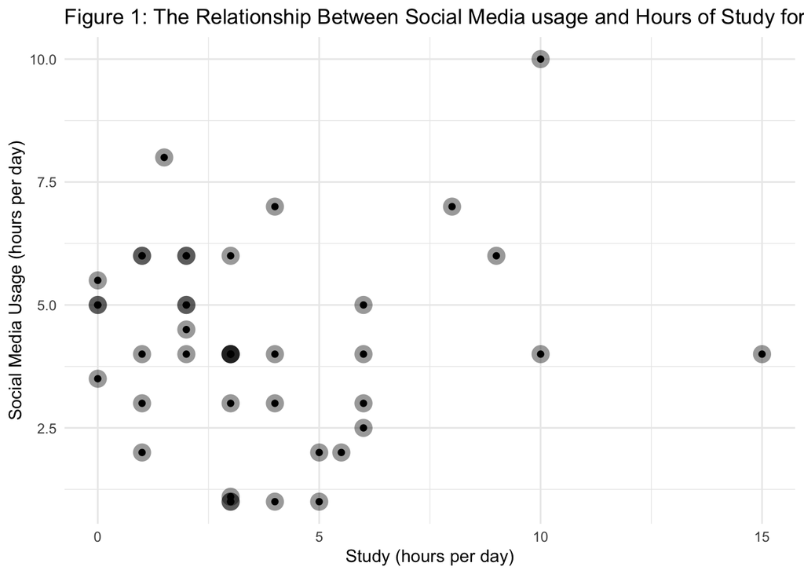

```r
#attach(social_media.xlsx)
ggplot(x, aes(study_hours_average, hours_spent)) + geom_point() + labs(x="Study (hours per day)", y="Social Media Usage (hours per day)") + ggtitle("Figure 1: The Relationship Between Social Media usage and Hours of Study for University Students") +
      theme(plot.title = element_text(hjust=0.5)) + geom_point(shape = 16, size = 5, alpha = .4) + theme_minimal() + scale_colour_gradient(low = "#0091ff", high = "#f0650e")
```

There was a lack of relationship between hours spent studying and hours spent on social media daily, evidenced by the scatterplot Figure 1 and the R value of 0.1 (signifying weak to no correlation). Students studied around 4 hours per day on average. It seems some responses are exaggerated — one respondent suggests they study 15 hours a daily — however even when outliers are discounted, medians are similar and likely do not significantly differ among usage groups.

## 3.2 How does the amount that university students use social media relate to their time spent sleeping?

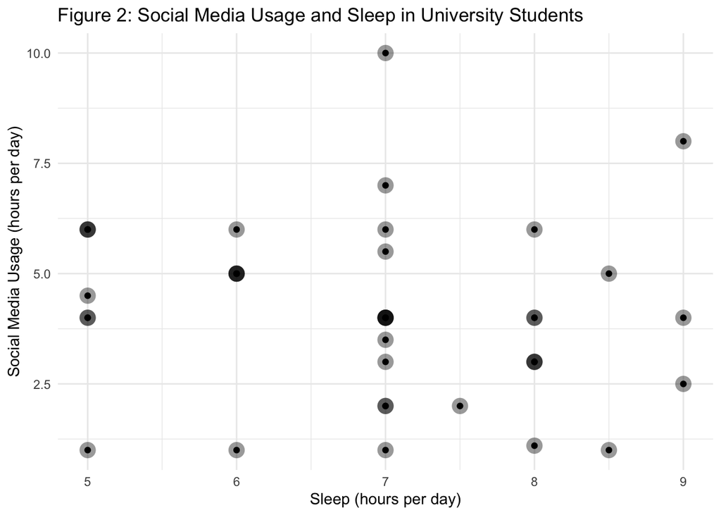

```r
#attach(social_media.xlsx)
ggplot(x, aes(sleep_hours_average, hours_spent)) + geom_point() + labs(x="Sleep (hours per day)", y="Social Media Usage (hours per day)") + ggtitle("Figure 2: Social Media Usage and Sleep in University Students") +
      theme(plot.title = element_text(hjust=0.5)) + geom_point(shape = 16, size = 5, alpha = .4) + theme_minimal() + scale_colour_gradient(low = "#0091ff", high = "#f0650e")
```

There is no evident relationship between students’ daily hours spent on social media and hours of sleep as seen in Figure 2.

## 3.3 How does social media use relate to stress levels among university students?

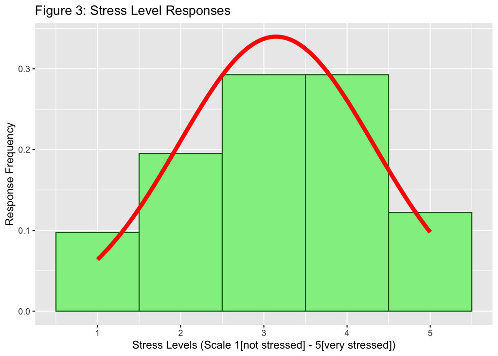

```r
ggplot(x, aes(x = stress_level)) + geom_histogram(aes(y = ..density..), binwidth=1, color="darkgreen", fill="lightgreen") + ggtitle("Figure 3: Stress Level Responses")  +  xlab("Stress Levels (Scale 1[not stressed] - 5[very stressed])") + ylab("Response Frequency") + stat_function(fun = dnorm, args = list(mean = mean(x$stress_level), sd = sd(x$stress_level)), col = "red", size = 2)
```

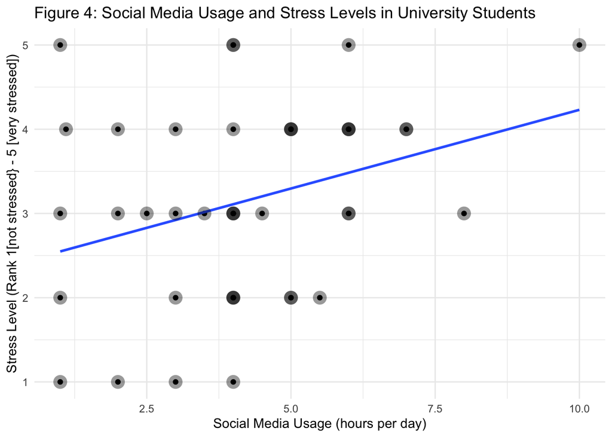

```r
ggplot(data = x, aes(x = hours_spent, y = stress_level)) +
  geom_point(color='black') +
  geom_smooth(method = "lm", se = FALSE) + labs(x="Social Media Usage (hours per day)", y="Stress Level (Rank 1[not stressed} - 5 [very stressed])") + ggtitle("Figure 4: Social Media Usage and Stress Levels in University Students") +
      theme(plot.title = element_text(hjust=0.5)) + geom_point(shape = 16, size = 5, alpha = .4) + theme_minimal() + scale_colour_gradient(low = "#0091ff", high = "#f0650e")
```

[figure not shown]

```r
l=lm(x$hours_spent~x$stress_level)
plot(x$hours_spent,l$rediduals, ylab="Residuals", main = "Figure 5: Residual Plot for Social Media Usage and Stress Levels")
abline(h=0)
```

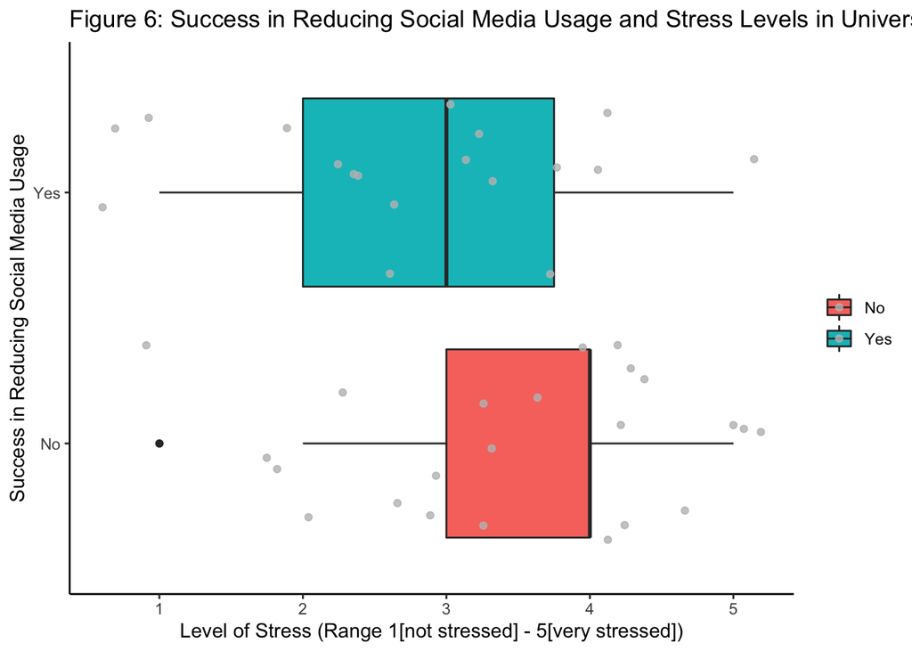

```r
x = x %>% drop_na(attempt_successful)
ggplot(x, aes(stress_level, attempt_successful, fill = (x$attempt_successful), na.rn = TRUE)) + geom_boxplot() + labs(x="Level of Stress (Range 1[not stressed] - 5[very stressed])", y= "Success in Reducing Social Media Usage") + ggtitle("Figure 6: Success in Reducing Social Media Usage and Stress Levels in University Students") + theme(plot.title = element_text(hjust = 0.5)) + theme_classic() + theme(legend.title = element_blank()) + geom_jitter(alpha=0.8,color="grey")
```

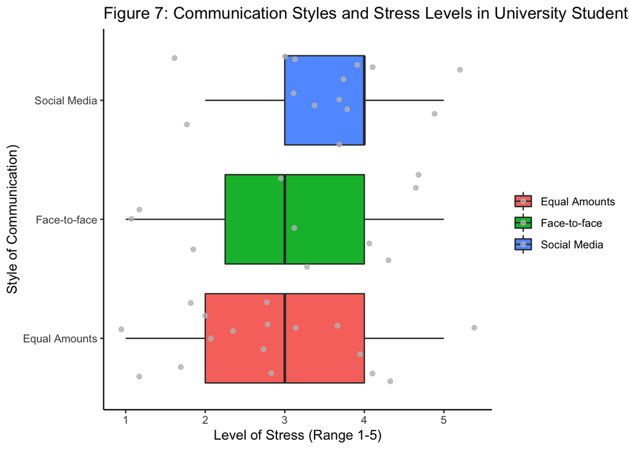

```r
ggplot(x, aes(stress_level, talk_or_face, fill = (x$talk_or_face))) + geom_boxplot() + labs(x="Level of Stress (Range 1-5)", y= "Style of Communication)") + ggtitle("Figure 7: Communication Styles and Stress Levels in University Students") + theme(plot.title = element_text(hjust = 0.5)) + theme_classic() + theme(legend.title = element_blank()) + geom_jitter(alpha=0.8,color="grey")
```

University students who mostly communicate via social media reported feeling more stressed (median=4) than students who mostly communicate face-to-face or equal amounts (50% face-to-face, 50% social media) (median=3) (Figure 7).

## 3.4 How do university students’ level of enjoyment of social media relate to their social media usage?

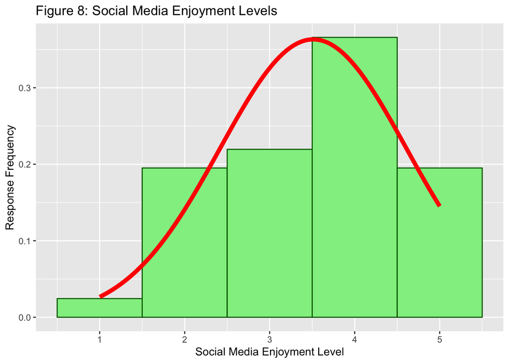

```r
ggplot(x, aes(x = social_media_like_level)) + geom_histogram(aes(y = ..density..), binwidth=1, color="darkgreen", fill="lightgreen") + ggtitle("Figure 8: Social Media Enjoyment Levels")  +  xlab("Social Media Enjoyment Level") + ylab("Response Frequency") + stat_function(fun = dnorm, args = list(mean = mean(x$social_media_like_level), sd = sd(x$social_media_like_level)), col = "red", size = 2)
```

Enjoyment of social media was measured on a 1 to 5 scale (Figure 8). Enjoyment levels were negatively skewed.

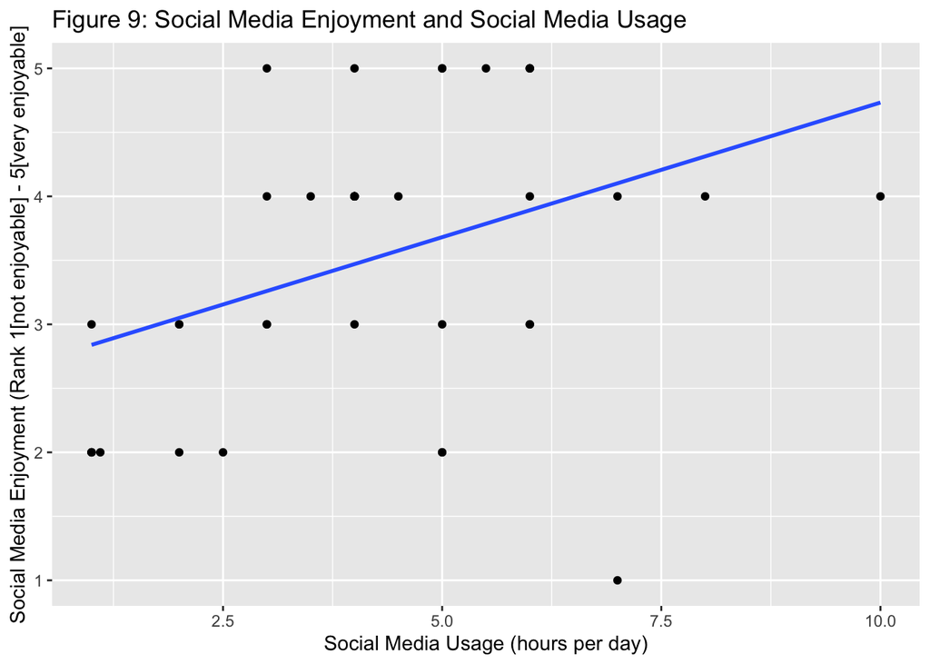

```r
ggplot(x, aes(hours_spent,social_media_like_level)) +
 geom_point() +
geom_smooth(method = "lm", se = FALSE) +
labs(title = "Figure 9: Social Media Enjoyment and Social Media Usage", x = "Social Media Usage (hours per day)" , y = "Social Media Enjoyment (Rank 1[not enjoyable] - 5[very enjoyable]")
```

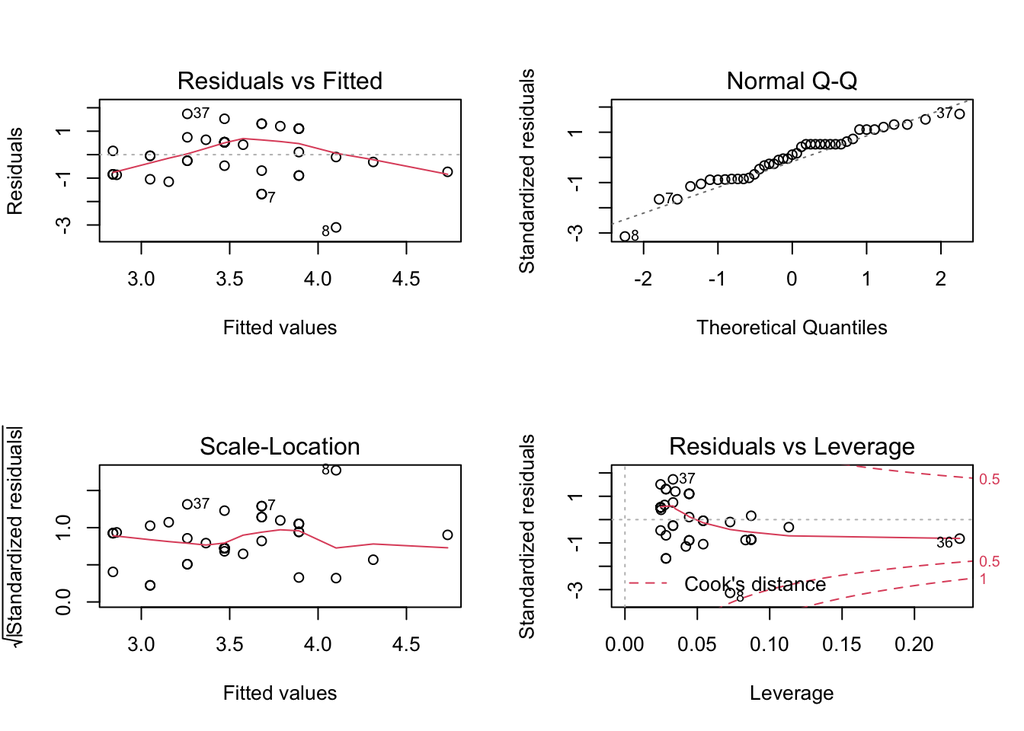

```r
#l=lm(hours_spent ~ social_media_like_level, data=x)
l=lm(social_media_like_level ~ hours_spent, data=x) #
par(mfrow = c(2, 2))
plot(l)
```

# 4 Articles

Reference 5: found adolescents using social media for more than 3 hours daily lack exercise habits and rest, sleep irregularly, and feel stressed.

Reference 7: found that since social media became accessible in 2007 with the iPhone’s release, adolescents are more likely to feel lonely and sleep less.

# 5 References

How Social Media Affects Student Productivity. (n.d.). Retrieved from https://www.sctcc.edu/news/10-20-2020/how-social-media-affects-student-productivity

Karim, F., Oyewande, A. A., Abdalla, L. F., Chaudhry Ehsanullah, R., & Khan, S. (n.d.). Social Media Use and Its Connection to Mental Health: A Systematic Review. Cureus, 12(6). doi:10.7759/cureus.8627

Rabasco, A. N., & Sheets, E. S. (n.d.). The effects of face-to-face and online social stress on emotion identification, 12. Retrieved from Zotero

Robinson, L. (n.d.). Social Media and Mental Health - HelpGuide.org. Retrieved from https://www.helpguide.org/articles/mental-health/social-media-and-mental-health.htm

Sano, M., Iwasa, H., Nakayama, C., Moriyama, N., Katsuyama, K., & Yasumura, S. (2020). Relationship between prolonged media usage and lifestyle habits among junior and senior high school students. [Nihon Kōshū Eisei Zasshi] Japanese Journal of Public Health. doi:10.11236/jph.67.6_380

Social Media Addiction. (n.d.). Retrieved from https://www.addictioncenter.com/drugs/social-media-addiction/

Twenge, S. by J. M. (n.d.). Have Smartphones Destroyed a Generation? The Atlantic. Retrieved from The Atlantic